# 08_analysis_kegg

Julie Bruun Brockhoff (s204519), Cecilie Kejlberg Leth (s204584), Amalie Drud Nielsen (s204560), Chrysillis Hellemann Polhaus (s153664), Lise Lotte Eriksen (s154123)

### Loading packages

```r
library(here)
library(readr)
library(tidyverse)
library(biomaRt)
library(clusterProfiler)
```

```r
library(enrichplot)
```

### Load data

```r
data <- read_tsv(file = here("data/03_dat_aug.tsv"))
```

### Get gene IDs for each gene name

Using ensembl and NCBI to retrieve all of the gene IDs for our data. The NCBI database is chosen because the IDs needs to match with the KEGG database. The IDs are then joined with the our data based on the gene names.

```r
#connect to ensembl to fetch IDs
mart <- useMart("ensembl",
                dataset = "hsapiens_gene_ensembl")

gene_info <- getBM(
  attributes = c("external_gene_name", "entrezgene_id"),
  filters = "external_gene_name",
  values = data |>
    pull(gene),
  mart = mart)

#Join the data and rearrange the new ID column after the old column.
data_with_ID <- data |>
  right_join(gene_info,
            by = c("gene" = "external_gene_name")) |>
  relocate(entrezgene_id,
           .after = gene)
```

### The cell lines are seperated into two different datasets with up- and downregulated DEGs. The DEGs are also ranjed

```r
#Separate data into the two cell lines DEGs with geneIDs
data_OVCAR3 <- data_with_ID |>
  filter(DEG_OVCAR3 == "Upregulated" |
           DEG_OVCAR3 == "Downregulated") |>
  dplyr::select(gene, entrezgene_id, OVCAR3_MOCK, OVCAR3_KO, log2FC_OVCAR3) |>
  mutate(rank_log2FC_OVCAR3 = rank(-log2FC_OVCAR3, ties.method = "min")) |>
   arrange(rank_log2FC_OVCAR3)

data_SKOV3 <- data_with_ID |>
  filter(DEG_SKOV3 == "Upregulated" |
           DEG_SKOV3 == "Downregulated") |>
  dplyr::select(gene, entrezgene_id, SKOV3_MOCK, OVCAR3_KO, log2FC_SKOV3) |>
  mutate(rank_log2FC_SKOV3 = rank(-log2FC_SKOV3, ties.method = "min")) |>
  arrange(rank_log2FC_SKOV3)


#save the geneIDs seperately for each cell line and type of regulation:
geneIDs_OVCAR3 <- data_OVCAR3 |>
  rename(geneIDs = entrezgene_id) |>
  pull(geneIDs) |>
  na.omit()

geneIDs_SKOV3 <- data_SKOV3 |>
  rename(geneIDs = entrezgene_id) |>
  pull(geneIDs) |>
  na.omit()
```

### KEGG enrichment for OVCAR3

```r
kegg_analysis_OVCAR3 <- enrichKEGG(gene = geneIDs_OVCAR3,
                                               organism = "hsa",
                                               pAdjustMethod = "BH",
                                               minGSSize = 10,
                                               maxGSSize = 500,
                                               qvalueCutoff = 0.05) |>
  as_tibble()
```

```
## Reading KEGG annotation online: "https://rest.kegg.jp/link/hsa/pathway"...
```

```
## Reading KEGG annotation online: "https://rest.kegg.jp/list/pathway/hsa"...
```

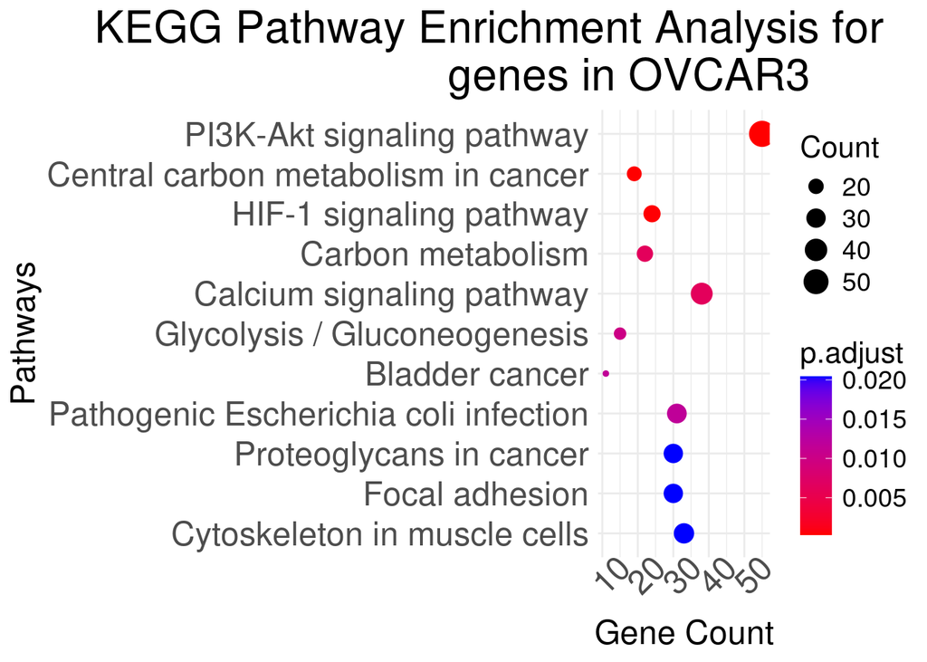

```r
plot_kegg_OVCAR3 <- kegg_analysis_OVCAR3 |>
  slice_min(order_by = p.adjust,
            n = 10) |>
  mutate(Description = fct_reorder(Description, p.adjust, .desc = TRUE)) |>
  ggplot(aes(x = Count,
             y = Description)) +
  geom_point(aes(size = Count,
                 color = p.adjust)) +
  scale_color_gradient(low = "red",
                       high = "blue",
                       name = "p.adjust") +
  labs(
    title = "KEGG Pathway Enrichment Analysis for \n genes in OVCAR3",
    x = "Gene Count",
    y = "Pathways") +
  theme_minimal() +
  theme(
    plot.title = element_text(size = 24,
                              hjust = 0.8),
    axis.text.x = element_text(size = 18,
                             angle = 45),
    axis.text.y = element_text(size = 18),
    axis.title = element_text(size = 18),
    legend.title = element_text(size = 16),
    legend.text = element_text(size = 14))

plot_kegg_OVCAR3
```

Several pathways was significantly for the OVCAR3 cell line for the up- and down-regulated genes. The most prominent pathways are related the cancer along with PI3K-Akt signaling pathway, this pathway is a pathway that regulates cell growth, apoptosis and cellular senescence.

The KEGG is saved in a png-file in the results folder:

```r
ggsave(filename = here("results/08_KEGG_OVCAR3.png"),
       plot = plot_kegg_OVCAR3,
       width = 10,
       height = 6)
```

### KEGG enrichment for SKOV3

[figure not shown]

```r
kegg_analysis_SKOV3 <- enrichKEGG(gene = geneIDs_SKOV3,
                                               organism = "hsa",
                                               pAdjustMethod = "BH",
                                               minGSSize = 10,
                                               maxGSSize = 500,
                                               qvalueCutoff = 0.05) |>
  as_tibble()

plot_kegg_SKOV3 <- kegg_analysis_SKOV3 |>
  slice_min(order_by = p.adjust,
            n = 10) |>
  mutate(Description = fct_reorder(Description, p.adjust, .desc = TRUE)) |>
  ggplot(aes(x = Count,
             y = Description)) +
  geom_point(aes(size = Count,
                 color = p.adjust)) +
  scale_color_gradient(low = "red",
                       high = "blue",
                       name = "p.adjust") +
  labs(
    title = "KEGG Pathway Enrichment Analysis for \n genes in SKOV3",
    x = "Gene Count",
    y = "Pathways") +
  theme_minimal() +
  theme(
    plot.title = element_text(size = 24,
                              hjust = 0.8),
    axis.text.x = element_text(size = 18,
                             angle = 45),
    axis.text.y = element_text(size = 18),
    axis.title = element_text(size = 18),
    legend.title = element_text(size = 16),
    legend.text = element_text(size = 14))

plot_kegg_SKOV3
```

There are no pathways found for the SKOV3 cell line.

The KEGG is saved in a png-file in the results folder:

```r
ggsave(filename = here("results/08_KEGG_SKOV3.png"),
       plot = plot_kegg_SKOV3,
       width = 10,
       height = 6)
```

### Conclusion

The enrichment analysis of SKOV3 didn’t reveal any significant pathways.

These results indicate that the KO OVCAR3 cell line and the baseline OVCAR3 cell is a better model for cancer compared to SKOV3 as this cell line doesn’t show any significant differences between the two set of DEGs in the baseline compared to the KO cell line.